# WheatBreedingPipeline

MaoHuang

5/20/2022

## Set up founder information

Youd could get estimates of effective population size `Ne` using different methods. One example: The average LD is approximately =`1/(1+4Nec)`,([Sved, 1971](https://www.sciencedirect.com/science/article/pii/0040580971900116)) where `Ne` is the effective population size, and `c` is recombination rate among all sites, assumed to be 0.5. The average `LD` can be estimated using marker data. We pick `1000` as `Ne`.

```r
library(AlphaSimR)
Ne<-1000
nInd<-200
nChr<-21
segSites<-500
founderHap<-runMacs2(nInd=nInd,nChr=nChr,segSites=segSites,Ne=Ne,inbred=TRUE,ploidy=2L,returnCommand=FALSE)
```

```r
SP<-SimParam$new(founderHap)
nSnp<-100
SP$addSnpChip(nSnpPerChr=nSnp)

nQtl<-100
varE<-1   # h2= varG/(varG+varE) =0.5
SP$addTraitA(nQtlPerChr=nQtl, mean=0,var=1,corA=NULL)

SP$setTrackRec(TRUE)
founderpop <- newPop(founderHap, simParam=SP)
founderpop<-setPheno(founderpop,varE=varE,simParam=SP)
```

We add SNP Chip for genotyping downstream populations, The number of SNPs per chromosome = 100

AlphaSimR stores each individual using unique numbers A plot= many individuals= a population If you use Bulking method May require simulating multiple populations in parallel

```r
nParent<-20
nCross<-75
ntimes<-3
founderParent<-selectInd(pop=founderpop,nInd=nParent,trait=1,use="rand",simParam=SP)

###### How to repeat those same set of crosses for 3 times???!!!
Parentpop<-founderParent


F1_All<-NULL
F1_nCross<-NULL
for (i in 1:nCross){
  F1<-randCross(Parentpop,nCrosses=1,nProgeny=3,simParam=SP)
  F1_nCross<-c(F1_nCross,F1)
  F1_All<-c(F1_All,F1[1],F1[2],F1[3])
}

## Pretend each F1 plant self to produce 1 head, and each head has 8 seeds.
## Hence each F1 can produce F2 plants=8
nseeds<-6
nF3<-200
F2sel<-sample(1:225,nF3)       ### Randomly Select 200 HRs from F2 plants, self to make 200 F3s plots

F2_Select<-NULL       ### F2 HRs
F3_All<-NULL
for (i in F2sel){
  F2<-self(F1_All[[i]],nProgeny=nseeds, simParam=SP)
  F3<-self(F2,nProgeny=nseeds,simParam=SP)

  F2_Select<-c(F2_Select,F2)
  F3_All<-c(F3_All,F3)
}
```

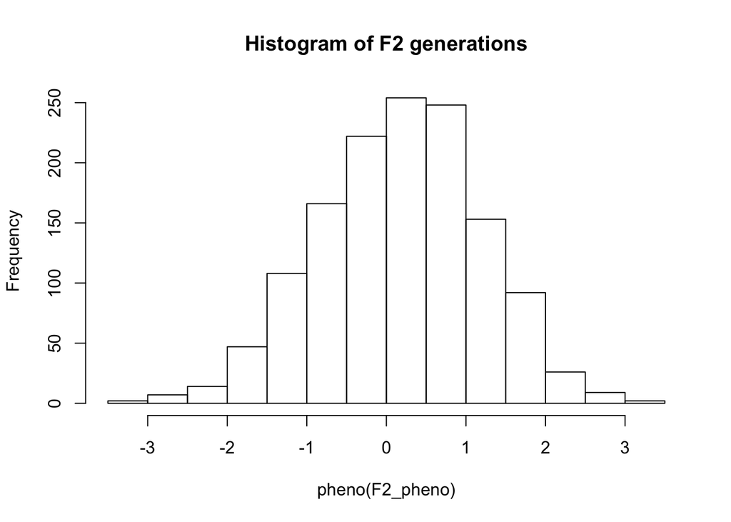

```r
F2_All<-NULL
for (i in 1:length(F1_All)){
   F2s<-self(F1_All[[i]],nProgeny=nseeds,simParam=SP)
   F2_All<-c(F2_All,F2)
}
   F2_one<-mergePops(F2_All)
   F2_pheno<-setPheno(F2_one,varE=varE)
   hist(pheno(F2_pheno),main="Histogram of F2 generations")
```

```r
nF4<-120
F3sel<-sample(1:200,nF4)                 ### Randomly Select for 120 F3 plots, self to make 120 F4s plots

F4_All<-NULL
for (i in F3sel){
  F4<-self(F3_All[[i]],nProgeny=nseeds,simParam=SP)
  F4_All<-c(F4_All,F4)
}

nHeads<-115    ### Randomly Select 115 heads from within each of the 120 F4 plots. Later self to get F5 seeds
F4_Allplants<-NULL
for (i in 1:length(F4_All)){
  F4_Indi<-selectInd(F4_All[[i]],nInd=nHeads,trait=1,use="rand",simParam=SP)
  F4_Allplants<-c(F4_Allplants,F4_Indi)

}

F4_PopMerge<-mergePops(F4_Allplants)  ### Merge the 120 populations (115*120=13800 plants) into one population
# F45MergeSelf<-self(F4_Pop)
F4_5nsel<-1000
### Randomly select 1000 out of 13,800 plots of F4:5 HR: Because each F4:5 head comes from the same F4 plants, so this random selection on F4:5 heads can be operated as Randomly selecting on F4 individual plant.

F4_Select<-selectInd(pop=F4_PopMerge,nInd=F4_5nsel,trait=1,use="rand",simParam=SP)

F4_5<-self(F4_Select,nProgeny=nseeds,simParam=SP)
F4_5_HR<-setPheno(pop=F4_5,varE=varE,simParam=SP)

### Now we have to start label these 1000 HR plots (with 8 individuals per HR, and a total of 8000 individuals)  based on F4 IDs
### We do these by split this one whole population into 1000 sub-populations, easier for tracking
F4ID<-F4_Select@id         ### Mark each F4:5 individual plant in the F4_5_HR, is coming from which F4ID
F4ID_toF5<-rep(F4ID,each=nseeds)
F4to5ID<-cbind(F4ID_toF5,F4_5_HR@id)

colnames(F4to5ID)<-c("F4ID","F5ID")
F4to5ID<-as.data.frame(F4to5ID)

All_F45<-NULL
PhenoPerPlot<-NULL
for (i in 1:nlevels(F4to5ID$F4ID)){           # Split this one whole population into 1000 (plots)
  F5IDs<-droplevels(F4to5ID[F4to5ID$F4ID==levels(F4to5ID$F4ID)[i],]$F5ID)
  subposition<-which(F4_5_HR@id%in%F5IDs)     # Subset poplation based on position of 1-8000
  EachF45<-F4_5_HR[subposition]
  All_F45<-c(All_F45,EachF45)
}
```

```r
# Here is the function that we could evaluate the phenotypic/GEBV/etc of each plot that is a "mini population"
# Function to evaluate each bulked plots}
Bulk_fnc<-function(InputPoplist,Select_position,nEnd_select){

NextYr_All<-NULL
PhenoPerPlot<-NULL
for (i in Select_position){
                                                          ## Example of YR1, selected out 450 plots
  NextYr<-self(InputPoplist[[i]] ,nProgeny=nseeds,simParam=SP)   ## Self to get NextYr
  PhenoNextYr<-setPheno(NextYr,varE=varE,simParam=SP)       ## Set Pheno
  MeanPhenoNextYr<-mean(PhenoNextYr@pheno)         # Mean phenotype per Plot !!!! You could change to GEBVs

  NextYr_All<-c(NextYr_All,PhenoNextYr)                    # All selfed plots stored in a list
  PhenoPerPlot<-c(PhenoPerPlot,MeanPhenoNextYr)      # Pheno mean per Plot/population
}
  nEnd_select<-nEnd_select
  Pheno_order<-cbind(1:length(Select_position),PhenoPerPlot)   ## Add the selected Plot/population numeric order
  Selected_position<-Pheno_order[order(-Pheno_order[,2]),1][1:nEnd_select]  ## select the Top ones

  return(list(Selected_position_output=Selected_position,Pop_All_output=NextYr_All))
}
```

```r
F1_pop<-mergePops(F1_All)  #225
F2_pop<-mergePops(F2_All)  #225
F3_pop<-mergePops(F3_All)  #200
F4_pop<-mergePops(F4_All)  #120
```

# Self each of these F4:5 plants to get F4:6, bulck as YR1

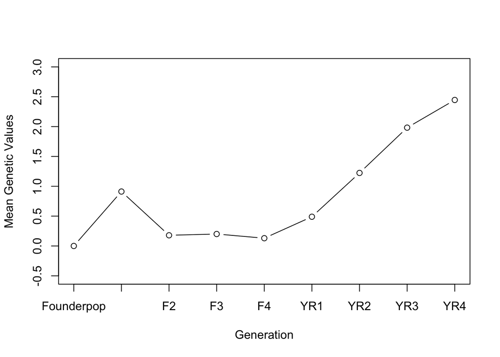

```r
YR1sel<-450
YR2sel<-100
YR3sel<-25
YR4sel<-25

YR1_Bulk<-Bulk_fnc(InputPoplist=All_F45,Select_position=c(1:nlevels(F4to5ID$F4ID)),nEnd_select=YR1sel)
YR1_All<-YR1_Bulk$Pop_All_output
YR1_select_position<-YR1_Bulk$Selected_position

### Subset the YR1s, self to get YR2s
YR2_Bulk<-Bulk_fnc(InputPoplist = YR1_All, Select_position = YR1_select_position,nEnd_select = YR2sel)
YR2_All<-YR2_Bulk$Pop_All_output
YR2_select_position<-YR2_Bulk$Selected_position

YR3_Bulk<-Bulk_fnc(InputPoplist = YR2_All, Select_position = YR2_select_position,nEnd_select = YR3sel)
YR3_All<-YR3_Bulk$Pop_All_output
YR3_select_position<-YR3_Bulk$Selected_position

YR4_Bulk<-Bulk_fnc(InputPoplist = YR3_All, Select_position = YR3_select_position,nEnd_select = YR4sel)  ## Keep All 25
YR4_All<-YR4_Bulk$Pop_All_output

#Estimate the genetic Mean value compared to founders

YR1_one<-mergePops(YR1_All)  #1000
YR2_one<-mergePops(YR2_All)  #450
YR3_one<-mergePops(YR3_All)  #100
YR4_one<-mergePops(YR4_All)  #25

YR_list<-NULL
YR_list<-c(YR_list,founderpop,F1,F2,F3,F4,YR1_one,YR2_one,YR3_one,YR4_one)
meanPop<-unlist(lapply(YR_list,meanG))

library(ggplot2)
plot(meanPop,type="b",xlab="Generation",ylab="Mean Genetic Values",xaxt = "n",ylim=c(-0.5,3));axis(1,at=c(1:9),labels=c("Founderpop","F1","F2","F3","F4","YR1","YR2","YR3","YR4"),xlim=c(-2,3))
```

# If we make the selection criterio being GEBVs, and the training population is being built based on the founders (or other populations)

Change this function is to replace the Set pheno to become set EBV

```r
Bulk_fnc2<-function(InputPoplist,Select_position,nEnd_select=100){
NextYr_All<-NULL
PhenoPerPlot<-NULL
GSmodel<-RRBLUP(founderpop,traits=1,simParam=SP)

for (i in Select_position){
                                                          ## Example of YR1, selected out 450 plots
  NextYr<-self(InputPoplist[[i]] ,nProgeny=nseeds,simParam=SP)   ## Self to get NextYr

  PhenoNextYr<-setEBV(InputPoplist[[i]],GSmodel,simParam=SP)  ## Set EBV

  MeanPhenoNextYr<-mean(PhenoNextYr@pheno)         # Mean phenotype per Plot !!!! You could change to GEBVs

  NextYr_All<-c(NextYr_All,NextYr)                    # All selfed plots stored in a list
  PhenoPerPlot<-c(PhenoPerPlot,MeanPhenoNextYr)      # Pheno mean per Plot/population
}
  nEnd_select<-nEnd_select
  Pheno_order<-cbind(1:length(Select_position),PhenoPerPlot)   ## Add the selected Plot/population numeric order
  Selected_position<-Pheno_order[order(-Pheno_order[,2]),1][1:nEnd_select]  ## select the Top ones

  return(list(Selected_position_output=Selected_position,Pop_All_output=NextYr_All))
}
```

Return the previous chunk where you execute the functions on YR1, YR2, YR3, and YR4

[figure not shown]